# uncertainty

Harrison Leduc

2024-04-16

#### Libraries

```r
library(dplyr)
library(sf)
library(terra)
library(parallel)
```

#### Data Import

```r
data_dir <- here::here("external/afcdata")

flds <- sfarrow::st_read_parquet(
  file.path(data_dir, "mapped_fields_final.parquet"))

ctlg <- readr::read_csv(
  file.path(data_dir, "label_catalog_allclasses.csv"))
```

#### Spatial Features

```r
polybox <- function(x, y, w = 0.0025, crs = 4326) {
  dw <- cbind(c(x - w, x + w, x + w, x - w, x - w),
              c(y + w, y + w, y - w, y - w, y + w))
  st_sf(geometry = st_sfc(st_polygon(list(dw))), crs = crs)
}
```

#### Label Uncertainty

```r
# Adjust data to only include sites where at least 3 people measured
sites_mapped_gt2 <- ctlg %>%
  group_by(Class, name) %>%
  count() %>%
  ungroup() %>%
  filter(n > 2)
sites_mapped_gt2
```

```
## # A tibble: 2,490 × 3
##    Class name          n
##    <chr> <chr>     <int>
##  1 1b    AO2853240     5
##  2 1b    BF0771815     4
##  3 1b    BF0864707     5
##  4 1b    BJ0013251     5
##  5 1b    CI0440803     5
##  6 1b    CM0309196     5
##  7 1b    GH0185154     4
##  8 1b    GH0407566     4
##  9 1b    ML3114895     5
## 10 1b    ML3702044     5
## # ℹ 2,480 more rows
```

```r
# Must use subset or else breaks computer. Several mclapply statements are
# commented out in case they will benefit future user.
# Line below (56) has code for entire dataset.
multi_site_list <- lapply(1:800, function(x) {
#multi_site_list <- lapply(1:nrow(sites_mapped_gt2), function(x) {

  multi_site <- sites_mapped_gt2 %>% slice(x)

# Filter the associations for the selected site
  multi_site_assns <- ctlg %>% filter(name == multi_site$name)

# Create an empty raster with the same extent as the target site
  target <- multi_site_assns %>%
    slice(1) %>%
    mutate(polybox(x, y)) %>%
    st_as_sf()

  # Rasterize at 224x224 pixels
  r <- rast(ext(target), nrows = 224, ncols = 224, crs = "EPSG:4326")
  values(r) <- 0

  # Process each association
  multi_site_assnsr <- lapply(1:nrow(multi_site_assns), function(x) {
    assn <- multi_site_assns[x, ]
    if (assn$nflds > 0) {
      assn_flds <- flds %>%
        filter(assignment_id == assn$assignment_id)
      r <- rasterize(assn_flds, r, background = 0)
    } else {
      r
    }
    return(r)
  }) %>% do.call(c, .)
})
# a list of rasters for each site
head(multi_site_list)
```

```
## [[1]]
## class       : SpatRaster
## dimensions  : 224, 224, 8  (nrow, ncol, nlyr)
## resolution  : 2.232143e-05, 2.232143e-05  (x, y)
## extent      : 14.219, 14.224, -14.4, -14.395  (xmin, xmax, ymin, ymax)
## coord. ref. : lon/lat WGS 84 (EPSG:4326)
## source(s)   : memory
## names       : layer, layer, layer, layer, layer, layer, ...
## min values  :     0,     0,     0,     0,     0,     0, ...
## max values  :     1,     1,     1,     1,     1,     1, ...
##
## [[2]]
## class       : SpatRaster
## dimensions  : 224, 224, 9  (nrow, ncol, nlyr)
## resolution  : 2.232143e-05, 2.232143e-05  (x, y)
## extent      : 0.289, 0.294, 11.065, 11.07  (xmin, xmax, ymin, ymax)
## coord. ref. : lon/lat WGS 84 (EPSG:4326)
## source(s)   : memory
## names       : layer, layer, layer, layer, layer, layer, ...
## min values  :     0,     0,     0,     0,     0,     0, ...
## max values  :     1,     1,     1,     1,     1,     1, ...
##
## [[3]]
## class       : SpatRaster
## dimensions  : 224, 224, 8  (nrow, ncol, nlyr)
## resolution  : 2.232143e-05, 2.232143e-05  (x, y)
## extent      : -3.976, -3.971, 10.245, 10.25  (xmin, xmax, ymin, ymax)
## coord. ref. : lon/lat WGS 84 (EPSG:4326)
## source(s)   : memory
## names       : lyr.1, layer, layer, layer, layer, layer, ...
## min values  :     0,     0,     0,     0,     0,     0, ...
## max values  :     0,     1,     1,     1,     1,     1, ...
##
## [[4]]
## class       : SpatRaster
## dimensions  : 224, 224, 7  (nrow, ncol, nlyr)
## resolution  : 2.232143e-05, 2.232143e-05  (x, y)
## extent      : 3.179, 3.184, 11.87, 11.875  (xmin, xmax, ymin, ymax)
## coord. ref. : lon/lat WGS 84 (EPSG:4326)
## source(s)   : memory
```

[output cut: 10 more lines]

```
## source(s)   : memory
## names       : lyr.1, lyr.1, lyr.1, lyr.1, lyr.1, lyr.1, ...
## min values  :     0,     0,     0,     0,     0,     0, ...
## max values  :     0,     0,     0,     0,     0,     0, ...
##
## [[6]]
## class       : SpatRaster
## dimensions  : 224, 224, 8  (nrow, ncol, nlyr)
## resolution  : 2.232143e-05, 2.232143e-05  (x, y)
## extent      : 14.609, 14.614, 7.71, 7.715  (xmin, xmax, ymin, ymax)
## coord. ref. : lon/lat WGS 84 (EPSG:4326)
## source(s)   : memory
## names       : layer, layer, layer, layer, layer, layer, ...
## min values  :     0,     0,     0,     0,     0,     0, ...
## max values  :     1,     1,     1,     1,     1,     1, ...
```

#### Calculations

```r
thresholds <- seq(0, 1, 0.2)
reclmat <- data.frame(
  lower = thresholds[-length(thresholds)],
  upper = thresholds[-1],
  index = 1:5,
  class = c("No field, high confidence", "No field, medium confidence", "Uncertain", "Field, medium confidence", "Field, high confidence")
)


pfield_list <- lapply(1:length(multi_site_list), function(x) {
  app_result <- app(multi_site_list[[x]], sum)
  nlyr_result <- nlyr(multi_site_list[[x]])
  app_result / nlyr_result
})

conf_class_list <- lapply(1:length(pfield_list), function(x) {
  classify(pfield_list[[x]], rcl = reclmat[, -4], include.lowest = TRUE)
})

# levels() from pdf doesn't work for lapply but categories() does
conf_class_list <- lapply(1:length(conf_class_list), function(x) {
  categories(conf_class_list[[x]], value = reclmat[, 3:4])
})
```

#### Calculations + Formatting

```r
conf_table <- lapply(1:length(conf_class_list), function(x) {
  freq(conf_class_list[[x]])
})

nofld <- lapply(1:length(pfield_list), function(x) {
  mask(1 - pfield_list[[x]], pfield_list[[x]] < 0.5, maskvalue = 0, updatevalue = 0)
})

fld <- lapply(1:length(pfield_list), function(x) {
  mask(pfield_list[[x]], pfield_list[[x]] >= 0.5, maskvalue = 0, updatevalue = 0)
})
#fld <- mclapply(1:length(pfield_list), function(x) {
#  mask(pfield_list[[x]], pfield_list[[x]] >= 0.5, maskvalue = 0, updatevalue = 0)
#}, mc.cores = 4)

fld_nofld_conf <- lapply(1:length(fld), function(x) {
  c(fld[[x]], nofld[[x]], fld[[x]] + nofld[[x]])
})
#fld_nofld_conf <- mclapply(1:length(fld), function(x) {
#  c(fld[[x]], nofld[[x]], fld[[x]] + nofld[[x]])
#}, mc.cores = 4)

fld_nofld_conf <- lapply(1:length(fld_nofld_conf), function(x) {
  names(fld_nofld_conf[[x]]) <- c("field agreement", "no field agreement", "overall agreement")
  return(fld_nofld_conf[[x]])
})
```

#### Example Site

```r
#insight to the number of pixels (counts) in each category for the site
conf_table[[9]]
```

```
##   layer                       value count
## 1     1   No field, high confidence  3379
## 2     1 No field, medium confidence  4798
## 3     1                   Uncertain  7041
## 4     1    Field, medium confidence 23867
## 5     1      Field, high confidence 11091
```

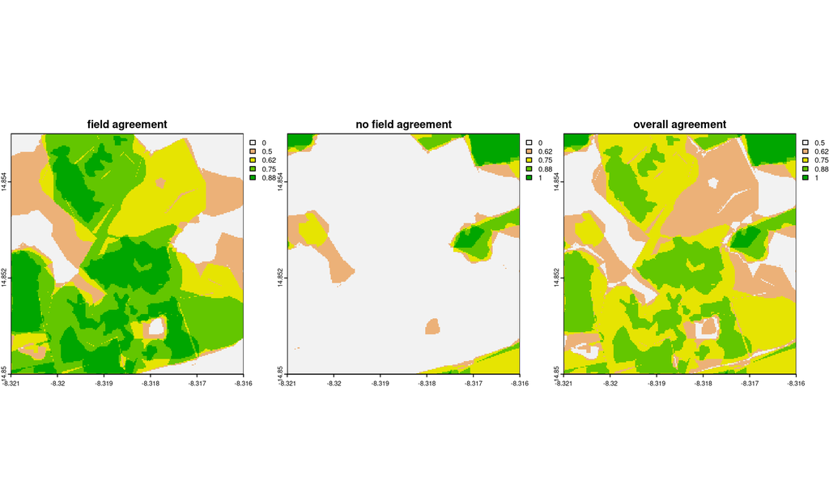

```r
plot(fld_nofld_conf[[9]], nr = 1)
```

For this site, we see that the field agreement averaged to:

```r
global(fld_nofld_conf[[9]][[1]], mean)
```

```
##                      mean
## field agreement 0.5970484
```

The no field agreement averaged to:

```r
global(fld_nofld_conf[[9]][[2]], mean)
```

```
##                         mean
## no field agreement 0.1290557
```

It is important to understand what the percentages mean. 0.00 represents no field. 1.00 represents a field. The closer to 0, the more overall agreement on land NOT being a field.

Knowing the average overall agreement does not provide as much insight as usual averages would. Due to the data, knowing where the average overall agreement lies on a 0-1 scale simply informs if the site tends to have more crop fields than non-crop fields. i.e.,

```r
global(fld_nofld_conf[[9]][[3]], mean)
```

```
##                        mean
## overall agreement 0.7261041
```

#### Entire Dataset Analysis

all_fld_means and all_nofld_means (below) both create a list with every sites average agreement for field and no field respectively.

```r
all_fld_means <- lapply(1:length(fld_nofld_conf), function(x) {
  global(fld_nofld_conf[[x]][[1]], mean)
})
head(all_fld_means)
```

```
## [[1]]
##                      mean
## field agreement 0.4993672
##
## [[2]]
##                      mean
## field agreement 0.4882392
##
## [[3]]
##                     mean
## field agreement 0.179533
##
## [[4]]
##                       mean
## field agreement 0.01748132
##
## [[5]]
##                 mean
## field agreement    0
##
## [[6]]
##                      mean
## field agreement 0.3905104
```

```r
all_nofld_means <- lapply(1:length(fld_nofld_conf), function(x) {
  global(fld_nofld_conf[[x]][[2]], mean)
})
head(all_nofld_means)
```

```
## [[1]]
##                         mean
## no field agreement 0.3217499
##
## [[2]]
##                         mean
## no field agreement 0.1926463
##
## [[3]]
##                       mean
## no field agreement 0.63069
##
## [[4]]
##                        mean
## no field agreement 0.826989
##
## [[5]]
##                    mean
## no field agreement    1
##
## [[6]]
##                         mean
## no field agreement 0.4268849
```

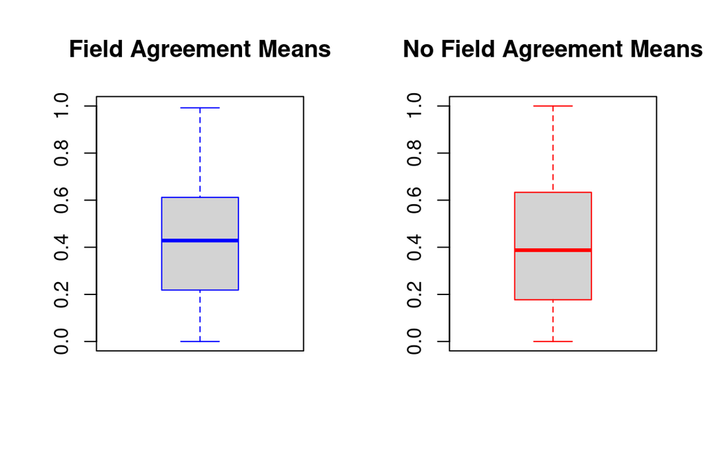

```r
par(mfrow = c(1, 2))
boxplot(unlist(all_fld_means), outline = TRUE, border = "blue",
        main = "Field Agreement Means", ylim = c(0, 1))
boxplot(unlist(all_nofld_means), outline = TRUE, border = "red",
        main = "No Field Agreement Means", ylim = c(0, 1))
```

From this subset, it seems that agreement for a field did not vary from agreement for a non-field. We will test below if extreme outliers impact this.

```r
# The results if we remove sites that are completely field or no field (0 or 1).
outlier <- c(0, 1)
all_fld_out <- setdiff(unlist(all_fld_means), outlier)
head(all_fld_out)
```

```
## [1] 0.49936723 0.48823918 0.17953304 0.01748132 0.39051040 0.33948280
```

```r
all_nofld_out <- setdiff(unlist(all_nofld_means), outlier)
head(all_nofld_out)
```

```
## [1] 0.3217499 0.1926463 0.6306900 0.8269890 0.4268849 0.5893765
```

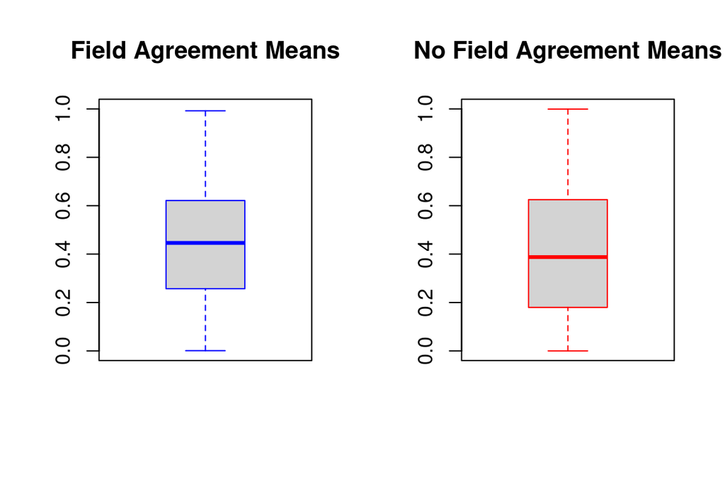

```r
par(mfrow = c(1, 2))
boxplot(all_fld_out, outline = TRUE, border = "blue",
        main = "Field Agreement Means", ylim = c(0, 1))
boxplot(all_nofld_out, outline = TRUE, border = "red",
        main = "No Field Agreement Means", ylim = c(0, 1))
```

```r
# with extreme outliers (Field Agreement Mean)
all_fld_means_mean <- mean(unlist(all_fld_means))
all_fld_means_mean
```

```
## [1] 0.4263731
```

```r
# without extreme outliers (Field Agreement Mean)
all_fld_out_mean <- mean(unlist(all_fld_out))
all_fld_out_mean
```

```
## [1] 0.4477375
```

```r
# with extreme outliers (No Field Agreement Mean)
all_nofld_means_mean <- mean(unlist(all_nofld_means))
all_nofld_means_mean
```

```
## [1] 0.4217211
```

```r
# without extreme outliers (No Field Agreement Mean)
all_nofld_out_mean <- mean(unlist(all_nofld_out))
all_nofld_out_mean
```

```
## [1] 0.4190437
```

This shows that the extreme scenarios make an impact, but not a large one. Since both agreement types are similar, it can be assumed that it is equally difficult to determine if a pixel is field or not field.